# Risk Factor Analysis

## Outcome Variable

**Outcome Variable:** ever_stunted

## Predictor Variables

**Intervention Variable:** fhtcm

**Adjustment Set:**

unadjusted

## Stratifying Variables

The analysis was stratified on these variable(s):

- agecat
- studyid
- country

## Data Summary

| agecat | studyid | country | fhtcm | ever_stunted | n_cell | n |
| --- | --- | --- | --- | --- | --- | --- |
| 0-24 months | ki1000304b-SAS-CompFeed | INDIA | >=167 cm | 0 | 137 | 907 |
| 0-24 months | ki1000304b-SAS-CompFeed | INDIA | >=167 cm | 1 | 273 | 907 |
| 0-24 months | ki1000304b-SAS-CompFeed | INDIA | <162 cm | 0 | 50 | 907 |
| 0-24 months | ki1000304b-SAS-CompFeed | INDIA | <162 cm | 1 | 180 | 907 |
| 0-24 months | ki1000304b-SAS-CompFeed | INDIA | [162-167) cm | 0 | 69 | 907 |
| 0-24 months | ki1000304b-SAS-CompFeed | INDIA | [162-167) cm | 1 | 198 | 907 |
| 0-24 months | ki1000304b-SAS-FoodSuppl | INDIA | >=167 cm | 0 | 23 | 399 |
| 0-24 months | ki1000304b-SAS-FoodSuppl | INDIA | >=167 cm | 1 | 83 | 399 |
| 0-24 months | ki1000304b-SAS-FoodSuppl | INDIA | <162 cm | 0 | 15 | 399 |
| 0-24 months | ki1000304b-SAS-FoodSuppl | INDIA | <162 cm | 1 | 148 | 399 |
| 0-24 months | ki1000304b-SAS-FoodSuppl | INDIA | [162-167) cm | 0 | 23 | 399 |
| 0-24 months | ki1000304b-SAS-FoodSuppl | INDIA | [162-167) cm | 1 | 107 | 399 |
| 0-24 months | ki1101329-Keneba | GAMBIA | >=167 cm | 0 | 598 | 1929 |
| 0-24 months | ki1101329-Keneba | GAMBIA | >=167 cm | 1 | 647 | 1929 |
| 0-24 months | ki1101329-Keneba | GAMBIA | <162 cm | 0 | 52 | 1929 |
| 0-24 months | ki1101329-Keneba | GAMBIA | <162 cm | 1 | 80 | 1929 |
| 0-24 months | ki1101329-Keneba | GAMBIA | [162-167) cm | 0 | 207 | 1929 |
| 0-24 months | ki1101329-Keneba | GAMBIA | [162-167) cm | 1 | 345 | 1929 |
| 0-24 months | ki1119695-PROBIT | BELARUS | >=167 cm | 0 | 9839 | 12537 |
| 0-24 months | ki1119695-PROBIT | BELARUS | >=167 cm | 1 | 1905 | 12537 |
| 0-24 months | ki1119695-PROBIT | BELARUS | <162 cm | 0 | 119 | 12537 |
| 0-24 months | ki1119695-PROBIT | BELARUS | <162 cm | 1 | 49 | 12537 |
| 0-24 months | ki1119695-PROBIT | BELARUS | [162-167) cm | 0 | 474 | 12537 |
| 0-24 months | ki1119695-PROBIT | BELARUS | [162-167) cm | 1 | 151 | 12537 |
| 0-24 months | ki1135781-COHORTS | GUATEMALA | >=167 cm | 0 | 16 | 496 |
| 0-24 months | ki1135781-COHORTS | GUATEMALA | >=167 cm | 1 | 48 | 496 |
| 0-24 months | ki1135781-COHORTS | GUATEMALA | <162 cm | 0 | 24 | 496 |
| 0-24 months | ki1135781-COHORTS | GUATEMALA | <162 cm | 1 | 269 | 496 |
| 0-24 months | ki1135781-COHORTS | GUATEMALA | [162-167) cm | 0 | 24 | 496 |
| 0-24 months | ki1135781-COHORTS | GUATEMALA | [162-167) cm | 1 | 115 | 496 |

[output cut: 60 more lines]

The following strata were considered:

- agecat: 0-24 months, studyid: ki1000304b-SAS-CompFeed, country: INDIA
- agecat: 0-24 months, studyid: ki1000304b-SAS-FoodSuppl, country: INDIA
- agecat: 0-24 months, studyid: ki1101329-Keneba, country: GAMBIA
- agecat: 0-24 months, studyid: ki1119695-PROBIT, country: BELARUS
- agecat: 0-24 months, studyid: ki1135781-COHORTS, country: GUATEMALA
- agecat: 0-6 months, studyid: ki1000304b-SAS-CompFeed, country: INDIA
- agecat: 0-6 months, studyid: ki1000304b-SAS-FoodSuppl, country: INDIA
- agecat: 0-6 months, studyid: ki1101329-Keneba, country: GAMBIA
- agecat: 0-6 months, studyid: ki1119695-PROBIT, country: BELARUS
- agecat: 0-6 months, studyid: ki1135781-COHORTS, country: GUATEMALA
- agecat: 6-24 months, studyid: ki1000304b-SAS-CompFeed, country: INDIA
- agecat: 6-24 months, studyid: ki1000304b-SAS-FoodSuppl, country: INDIA
- agecat: 6-24 months, studyid: ki1101329-Keneba, country: GAMBIA
- agecat: 6-24 months, studyid: ki1119695-PROBIT, country: BELARUS
- agecat: 6-24 months, studyid: ki1135781-COHORTS, country: GUATEMALA

## Methods Detail

We’re interested in the causal parameters $E[Y_a]$ for all values of $a \in \mathcal{A}$. These parameters represent the mean outcome if, possibly contrary to fact, we intervened to set all units to have $A=a$. Under the randomization and positivity assumptions, these are identified by the statistical parameters $\psi_a=E_W[E_{Y|A,W}(Y|A=a,W)]$. In addition, we’re interested in the mean of $Y$, $E[Y]$ under no intervention (the observed mean). We will estimate these parameters by using SuperLearner to fit the relevant likelihood factors – $E_{Y|A,W}(Y|A=a,W)$ and $p(A=a|W)$, and then updating our likelihood fit using a joint TMLE.

For unadjusted analyses ($W=\{\}$), initial likelihoods were estimated using Lrnr_glm to estimate the simple $E(Y|A)$ and Lrnr_mean to estimate $p(A)$. For adjusted analyses, a small library containing Lrnr_glmnet, Lrnr_xgboost, and Lrnr_mean was used.

Having estimated these parameters, we will then use the delta method to estimate relative risks and attributable risks relative to a prespecified baseline level of $A$.

# Results Detail

## Results Plots

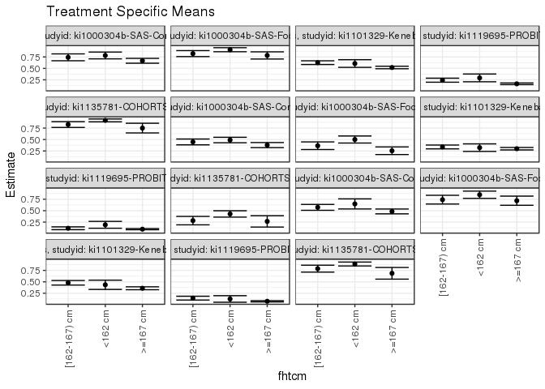

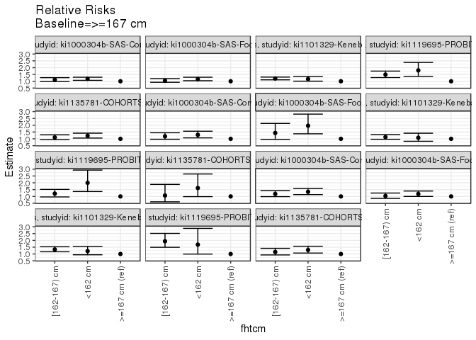

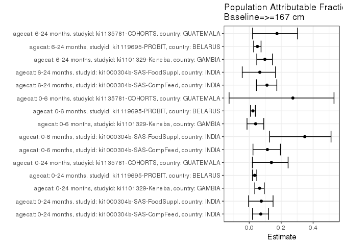

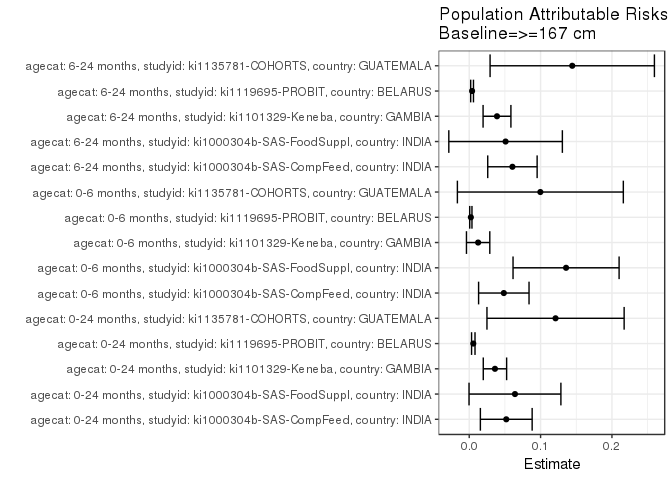

## Results Table

### Parameter: TSM

| agecat | studyid | country | intervention_level | baseline_level | estimate | ci_lower | ci_upper |
| --- | --- | --- | --- | --- | --- | --- | --- |
| 0-24 months | ki1000304b-SAS-CompFeed | INDIA | >=167 cm | NA | 0.6658537 | 0.6127457 | 0.7189616 |
| 0-24 months | ki1000304b-SAS-CompFeed | INDIA | <162 cm | NA | 0.7826087 | 0.7080228 | 0.8571946 |
| 0-24 months | ki1000304b-SAS-CompFeed | INDIA | [162-167) cm | NA | 0.7415730 | 0.6663543 | 0.8167918 |
| 0-24 months | ki1000304b-SAS-FoodSuppl | INDIA | >=167 cm | NA | 0.7830189 | 0.7044524 | 0.8615853 |
| 0-24 months | ki1000304b-SAS-FoodSuppl | INDIA | <162 cm | NA | 0.9079755 | 0.8635442 | 0.9524067 |
| 0-24 months | ki1000304b-SAS-FoodSuppl | INDIA | [162-167) cm | NA | 0.8230769 | 0.7573968 | 0.8887570 |
| 0-24 months | ki1101329-Keneba | GAMBIA | >=167 cm | NA | 0.5196787 | 0.4919194 | 0.5474381 |
| 0-24 months | ki1101329-Keneba | GAMBIA | <162 cm | NA | 0.6060606 | 0.5226836 | 0.6894376 |
| 0-24 months | ki1101329-Keneba | GAMBIA | [162-167) cm | NA | 0.6250000 | 0.5846032 | 0.6653968 |
| 0-24 months | ki1119695-PROBIT | BELARUS | >=167 cm | NA | 0.1622105 | 0.1441902 | 0.1802308 |
| 0-24 months | ki1119695-PROBIT | BELARUS | <162 cm | NA | 0.2916667 | 0.2067053 | 0.3766280 |
| 0-24 months | ki1119695-PROBIT | BELARUS | [162-167) cm | NA | 0.2416000 | 0.1976593 | 0.2855407 |
| 0-24 months | ki1135781-COHORTS | GUATEMALA | >=167 cm | NA | 0.7500000 | 0.6438067 | 0.8561933 |
| 0-24 months | ki1135781-COHORTS | GUATEMALA | <162 cm | NA | 0.9180887 | 0.8866571 | 0.9495203 |
| 0-24 months | ki1135781-COHORTS | GUATEMALA | [162-167) cm | NA | 0.8273381 | 0.7644428 | 0.8902335 |
| 0-6 months | ki1000304b-SAS-CompFeed | INDIA | >=167 cm | NA | 0.3780488 | 0.3223668 | 0.4337307 |
| 0-6 months | ki1000304b-SAS-CompFeed | INDIA | <162 cm | NA | 0.4890830 | 0.4291619 | 0.5490041 |
| 0-6 months | ki1000304b-SAS-CompFeed | INDIA | [162-167) cm | NA | 0.4473684 | 0.3835084 | 0.5112284 |
| 0-6 months | ki1000304b-SAS-FoodSuppl | INDIA | >=167 cm | NA | 0.2547170 | 0.1716684 | 0.3377656 |
| 0-6 months | ki1000304b-SAS-FoodSuppl | INDIA | <162 cm | NA | 0.5000000 | 0.4229082 | 0.5770918 |
| 0-6 months | ki1000304b-SAS-FoodSuppl | INDIA | [162-167) cm | NA | 0.3643411 | 0.2811902 | 0.4474920 |
| 0-6 months | ki1101329-Keneba | GAMBIA | >=167 cm | NA | 0.2991914 | 0.2722822 | 0.3261006 |
| 0-6 months | ki1101329-Keneba | GAMBIA | <162 cm | NA | 0.3225806 | 0.2402785 | 0.4048828 |
| 0-6 months | ki1101329-Keneba | GAMBIA | [162-167) cm | NA | 0.3374486 | 0.2953982 | 0.3794989 |
| 0-6 months | ki1119695-PROBIT | BELARUS | >=167 cm | NA | 0.0953678 | 0.0824845 | 0.1082512 |
| 0-6 months | ki1119695-PROBIT | BELARUS | <162 cm | NA | 0.1904762 | 0.1155722 | 0.2653802 |
| 0-6 months | ki1119695-PROBIT | BELARUS | [162-167) cm | NA | 0.1152000 | 0.0844850 | 0.1459150 |
| 0-6 months | ki1135781-COHORTS | GUATEMALA | >=167 cm | NA | 0.2653061 | 0.1415057 | 0.3891066 |
| 0-6 months | ki1135781-COHORTS | GUATEMALA | <162 cm | NA | 0.4285714 | 0.3591876 | 0.4979552 |
| 0-6 months | ki1135781-COHORTS | GUATEMALA | [162-167) cm | NA | 0.2826087 | 0.1904640 | 0.3747534 |
| 6-24 months | ki1000304b-SAS-CompFeed | INDIA | >=167 cm | NA | 0.4836066 | 0.4306738 | 0.5365393 |
| 6-24 months | ki1000304b-SAS-CompFeed | INDIA | <162 cm | NA | 0.6476190 | 0.5375474 | 0.7576907 |
| 6-24 months | ki1000304b-SAS-CompFeed | INDIA | [162-167) cm | NA | 0.5724638 | 0.5078540 | 0.6370736 |
| 6-24 months | ki1000304b-SAS-FoodSuppl | INDIA | >=167 cm | NA | 0.7179487 | 0.6178737 | 0.8180238 |
| 6-24 months | ki1000304b-SAS-FoodSuppl | INDIA | <162 cm | NA | 0.8481013 | 0.7687873 | 0.9274153 |
| 6-24 months | ki1000304b-SAS-FoodSuppl | INDIA | [162-167) cm | NA | 0.7407407 | 0.6451050 | 0.8363765 |
| 6-24 months | ki1101329-Keneba | GAMBIA | >=167 cm | NA | 0.3588571 | 0.3270632 | 0.3906510 |
| 6-24 months | ki1101329-Keneba | GAMBIA | <162 cm | NA | 0.4347826 | 0.3334476 | 0.5361176 |
| 6-24 months | ki1101329-Keneba | GAMBIA | [162-167) cm | NA | 0.4788360 | 0.4284576 | 0.5292144 |
| 6-24 months | ki1119695-PROBIT | BELARUS | >=167 cm | NA | 0.0739311 | 0.0606756 | 0.0871865 |
| 6-24 months | ki1119695-PROBIT | BELARUS | <162 cm | NA | 0.1250000 | 0.0535681 | 0.1964319 |
| 6-24 months | ki1119695-PROBIT | BELARUS | [162-167) cm | NA | 0.1431159 | 0.1015524 | 0.1846795 |
| 6-24 months | ki1135781-COHORTS | GUATEMALA | >=167 cm | NA | 0.6862745 | 0.5587566 | 0.8137925 |
| 6-24 months | ki1135781-COHORTS | GUATEMALA | <162 cm | NA | 0.8894231 | 0.8467467 | 0.9320994 |
| 6-24 months | ki1135781-COHORTS | GUATEMALA | [162-167) cm | NA | 0.7876106 | 0.7120987 | 0.8631225 |

### Parameter: E(Y)

| agecat | studyid | country | intervention_level | baseline_level | estimate | ci_lower | ci_upper |
| --- | --- | --- | --- | --- | --- | --- | --- |
| 0-24 months | ki1000304b-SAS-CompFeed | INDIA | NA | NA | 0.7177508 | 0.6751525 | 0.7603491 |
| 0-24 months | ki1000304b-SAS-FoodSuppl | INDIA | NA | NA | 0.8471178 | 0.8117623 | 0.8824733 |
| 0-24 months | ki1101329-Keneba | GAMBIA | NA | NA | 0.5557284 | 0.5335489 | 0.5779078 |
| 0-24 months | ki1119695-PROBIT | BELARUS | NA | NA | 0.1679030 | 0.1492221 | 0.1865839 |
| 0-24 months | ki1135781-COHORTS | GUATEMALA | NA | NA | 0.8709677 | 0.8414356 | 0.9004999 |
| 0-6 months | ki1000304b-SAS-CompFeed | INDIA | NA | NA | 0.4265193 | 0.3923837 | 0.4606550 |
| 0-6 months | ki1000304b-SAS-FoodSuppl | INDIA | NA | NA | 0.3904282 | 0.3423793 | 0.4384771 |
| 0-6 months | ki1101329-Keneba | GAMBIA | NA | NA | 0.3116657 | 0.2897893 | 0.3335421 |
| 0-6 months | ki1119695-PROBIT | BELARUS | NA | NA | 0.0976310 | 0.0843265 | 0.1109356 |
| 0-6 months | ki1135781-COHORTS | GUATEMALA | NA | NA | 0.3649852 | 0.3135088 | 0.4164615 |
| 6-24 months | ki1000304b-SAS-CompFeed | INDIA | NA | NA | 0.5441478 | 0.5023342 | 0.5859615 |
| 6-24 months | ki1000304b-SAS-FoodSuppl | INDIA | NA | NA | 0.7689076 | 0.7152410 | 0.8225741 |
| 6-24 months | ki1101329-Keneba | GAMBIA | NA | NA | 0.3977695 | 0.3716030 | 0.4239360 |
| 6-24 months | ki1119695-PROBIT | BELARUS | NA | NA | 0.0779232 | 0.0640302 | 0.0918162 |
| 6-24 months | ki1135781-COHORTS | GUATEMALA | NA | NA | 0.8306452 | 0.7924799 | 0.8688104 |

### Parameter: RR

| agecat | studyid | country | intervention_level | baseline_level | estimate | ci_lower | ci_upper |
| --- | --- | --- | --- | --- | --- | --- | --- |
| 0-24 months | ki1000304b-SAS-CompFeed | INDIA | >=167 cm | >=167 cm | 1.000000 | 1.0000000 | 1.000000 |
| 0-24 months | ki1000304b-SAS-CompFeed | INDIA | <162 cm | >=167 cm | 1.175346 | 1.0660500 | 1.295848 |
| 0-24 months | ki1000304b-SAS-CompFeed | INDIA | [162-167) cm | >=167 cm | 1.113718 | 0.9797436 | 1.266012 |
| 0-24 months | ki1000304b-SAS-FoodSuppl | INDIA | >=167 cm | >=167 cm | 1.000000 | 1.0000000 | 1.000000 |
| 0-24 months | ki1000304b-SAS-FoodSuppl | INDIA | <162 cm | >=167 cm | 1.159583 | 1.0370976 | 1.296535 |
| 0-24 months | ki1000304b-SAS-FoodSuppl | INDIA | [162-167) cm | >=167 cm | 1.051159 | 0.9246796 | 1.194937 |
| 0-24 months | ki1101329-Keneba | GAMBIA | >=167 cm | >=167 cm | 1.000000 | 1.0000000 | 1.000000 |
| 0-24 months | ki1101329-Keneba | GAMBIA | <162 cm | >=167 cm | 1.166222 | 1.0062100 | 1.351679 |
| 0-24 months | ki1101329-Keneba | GAMBIA | [162-167) cm | >=167 cm | 1.202666 | 1.1059337 | 1.307859 |
| 0-24 months | ki1119695-PROBIT | BELARUS | >=167 cm | >=167 cm | 1.000000 | 1.0000000 | 1.000000 |
| 0-24 months | ki1119695-PROBIT | BELARUS | <162 cm | >=167 cm | 1.798075 | 1.3586367 | 2.379646 |
| 0-24 months | ki1119695-PROBIT | BELARUS | [162-167) cm | >=167 cm | 1.489423 | 1.2706710 | 1.745834 |
| 0-24 months | ki1135781-COHORTS | GUATEMALA | >=167 cm | >=167 cm | 1.000000 | 1.0000000 | 1.000000 |
| 0-24 months | ki1135781-COHORTS | GUATEMALA | <162 cm | >=167 cm | 1.224118 | 1.0581791 | 1.416079 |
| 0-24 months | ki1135781-COHORTS | GUATEMALA | [162-167) cm | >=167 cm | 1.103117 | 0.9393488 | 1.295438 |
| 0-6 months | ki1000304b-SAS-CompFeed | INDIA | >=167 cm | >=167 cm | 1.000000 | 1.0000000 | 1.000000 |
| 0-6 months | ki1000304b-SAS-CompFeed | INDIA | <162 cm | >=167 cm | 1.293703 | 1.0724361 | 1.560623 |
| 0-6 months | ki1000304b-SAS-CompFeed | INDIA | [162-167) cm | >=167 cm | 1.183362 | 0.9691583 | 1.444908 |
| 0-6 months | ki1000304b-SAS-FoodSuppl | INDIA | >=167 cm | >=167 cm | 1.000000 | 1.0000000 | 1.000000 |
| 0-6 months | ki1000304b-SAS-FoodSuppl | INDIA | <162 cm | >=167 cm | 1.962963 | 1.3686077 | 2.815433 |
| 0-6 months | ki1000304b-SAS-FoodSuppl | INDIA | [162-167) cm | >=167 cm | 1.430376 | 0.9607469 | 2.129568 |
| 0-6 months | ki1101329-Keneba | GAMBIA | >=167 cm | >=167 cm | 1.000000 | 1.0000000 | 1.000000 |
| 0-6 months | ki1101329-Keneba | GAMBIA | <162 cm | >=167 cm | 1.078175 | 0.8226245 | 1.413113 |
| 0-6 months | ki1101329-Keneba | GAMBIA | [162-167) cm | >=167 cm | 1.127869 | 0.9671999 | 1.315227 |
| 0-6 months | ki1119695-PROBIT | BELARUS | >=167 cm | >=167 cm | 1.000000 | 1.0000000 | 1.000000 |
| 0-6 months | ki1119695-PROBIT | BELARUS | <162 cm | >=167 cm | 1.997279 | 1.3604840 | 2.932135 |
| 0-6 months | ki1119695-PROBIT | BELARUS | [162-167) cm | >=167 cm | 1.207954 | 0.9620344 | 1.516737 |
| 0-6 months | ki1135781-COHORTS | GUATEMALA | >=167 cm | >=167 cm | 1.000000 | 1.0000000 | 1.000000 |
| 0-6 months | ki1135781-COHORTS | GUATEMALA | <162 cm | >=167 cm | 1.615385 | 0.9857565 | 2.647172 |
| 0-6 months | ki1135781-COHORTS | GUATEMALA | [162-167) cm | >=167 cm | 1.065217 | 0.6028547 | 1.882192 |
| 6-24 months | ki1000304b-SAS-CompFeed | INDIA | >=167 cm | >=167 cm | 1.000000 | 1.0000000 | 1.000000 |
| 6-24 months | ki1000304b-SAS-CompFeed | INDIA | <162 cm | >=167 cm | 1.339144 | 1.1357742 | 1.578930 |
| 6-24 months | ki1000304b-SAS-CompFeed | INDIA | [162-167) cm | >=167 cm | 1.183739 | 0.9859106 | 1.421262 |
| 6-24 months | ki1000304b-SAS-FoodSuppl | INDIA | >=167 cm | >=167 cm | 1.000000 | 1.0000000 | 1.000000 |
| 6-24 months | ki1000304b-SAS-FoodSuppl | INDIA | <162 cm | >=167 cm | 1.181284 | 0.9987470 | 1.397182 |
| 6-24 months | ki1000304b-SAS-FoodSuppl | INDIA | [162-167) cm | >=167 cm | 1.031746 | 0.8532150 | 1.247634 |
| 6-24 months | ki1101329-Keneba | GAMBIA | >=167 cm | >=167 cm | 1.000000 | 1.0000000 | 1.000000 |
| 6-24 months | ki1101329-Keneba | GAMBIA | <162 cm | >=167 cm | 1.211576 | 0.9441972 | 1.554671 |
| 6-24 months | ki1101329-Keneba | GAMBIA | [162-167) cm | >=167 cm | 1.334336 | 1.1628669 | 1.531089 |
| 6-24 months | ki1119695-PROBIT | BELARUS | >=167 cm | >=167 cm | 1.000000 | 1.0000000 | 1.000000 |
| 6-24 months | ki1119695-PROBIT | BELARUS | <162 cm | >=167 cm | 1.690764 | 0.9932647 | 2.878069 |
| 6-24 months | ki1119695-PROBIT | BELARUS | [162-167) cm | >=167 cm | 1.935803 | 1.4923905 | 2.510959 |
| 6-24 months | ki1135781-COHORTS | GUATEMALA | >=167 cm | >=167 cm | 1.000000 | 1.0000000 | 1.000000 |
| 6-24 months | ki1135781-COHORTS | GUATEMALA | <162 cm | >=167 cm | 1.296016 | 1.0697107 | 1.570199 |
| 6-24 months | ki1135781-COHORTS | GUATEMALA | [162-167) cm | >=167 cm | 1.147661 | 0.9311244 | 1.414554 |

### Parameter: PAR

| agecat | studyid | country | intervention_level | baseline_level | estimate | ci_lower | ci_upper |
| --- | --- | --- | --- | --- | --- | --- | --- |
| 0-24 months | ki1000304b-SAS-CompFeed | INDIA | >=167 cm | NA | 0.0518972 | 0.0156169 | 0.0881774 |
| 0-24 months | ki1000304b-SAS-FoodSuppl | INDIA | >=167 cm | NA | 0.0640989 | -0.0002670 | 0.1284649 |
| 0-24 months | ki1101329-Keneba | GAMBIA | >=167 cm | NA | 0.0360496 | 0.0196844 | 0.0524149 |
| 0-24 months | ki1119695-PROBIT | BELARUS | >=167 cm | NA | 0.0056925 | 0.0032839 | 0.0081011 |
| 0-24 months | ki1135781-COHORTS | GUATEMALA | >=167 cm | NA | 0.1209677 | 0.0248482 | 0.2170873 |
| 0-6 months | ki1000304b-SAS-CompFeed | INDIA | >=167 cm | NA | 0.0484706 | 0.0131336 | 0.0838075 |
| 0-6 months | ki1000304b-SAS-FoodSuppl | INDIA | >=167 cm | NA | 0.1357112 | 0.0613964 | 0.2100261 |
| 0-6 months | ki1101329-Keneba | GAMBIA | >=167 cm | NA | 0.0124743 | -0.0038715 | 0.0288202 |
| 0-6 months | ki1119695-PROBIT | BELARUS | >=167 cm | NA | 0.0022632 | 0.0006927 | 0.0038336 |
| 0-6 months | ki1135781-COHORTS | GUATEMALA | >=167 cm | NA | 0.0996790 | -0.0165939 | 0.2159519 |
| 6-24 months | ki1000304b-SAS-CompFeed | INDIA | >=167 cm | NA | 0.0605413 | 0.0259272 | 0.0951554 |
| 6-24 months | ki1000304b-SAS-FoodSuppl | INDIA | >=167 cm | NA | 0.0509588 | -0.0286066 | 0.1305242 |
| 6-24 months | ki1101329-Keneba | GAMBIA | >=167 cm | NA | 0.0389124 | 0.0194110 | 0.0584137 |
| 6-24 months | ki1119695-PROBIT | BELARUS | >=167 cm | NA | 0.0039922 | 0.0020365 | 0.0059478 |
| 6-24 months | ki1135781-COHORTS | GUATEMALA | >=167 cm | NA | 0.1443707 | 0.0292238 | 0.2595175 |

### Parameter: PAF

| agecat | studyid | country | intervention_level | baseline_level | estimate | ci_lower | ci_upper |
| --- | --- | --- | --- | --- | --- | --- | --- |
| 0-24 months | ki1000304b-SAS-CompFeed | INDIA | >=167 cm | NA | 0.0723053 | 0.0206190 | 0.1212638 |
| 0-24 months | ki1000304b-SAS-FoodSuppl | INDIA | >=167 cm | NA | 0.0756671 | -0.0041818 | 0.1491666 |
| 0-24 months | ki1101329-Keneba | GAMBIA | >=167 cm | NA | 0.0648692 | 0.0347953 | 0.0940060 |
| 0-24 months | ki1119695-PROBIT | BELARUS | >=167 cm | NA | 0.0339036 | 0.0202478 | 0.0473691 |
| 0-24 months | ki1135781-COHORTS | GUATEMALA | >=167 cm | NA | 0.1388889 | 0.0199371 | 0.2434033 |
| 0-6 months | ki1000304b-SAS-CompFeed | INDIA | >=167 cm | NA | 0.1136421 | 0.0234622 | 0.1954942 |
| 0-6 months | ki1000304b-SAS-FoodSuppl | INDIA | >=167 cm | NA | 0.3475959 | 0.1276367 | 0.5120941 |
| 0-6 months | ki1101329-Keneba | GAMBIA | >=167 cm | NA | 0.0400247 | -0.0138708 | 0.0910552 |
| 0-6 months | ki1119695-PROBIT | BELARUS | >=167 cm | NA | 0.0231808 | 0.0077004 | 0.0384197 |
| 0-6 months | ki1135781-COHORTS | GUATEMALA | >=167 cm | NA | 0.2731044 | -0.1260997 | 0.5307900 |
| 6-24 months | ki1000304b-SAS-CompFeed | INDIA | >=167 cm | NA | 0.1112589 | 0.0451574 | 0.1727843 |
| 6-24 months | ki1000304b-SAS-FoodSuppl | INDIA | >=167 cm | NA | 0.0662743 | -0.0437567 | 0.1647061 |
| 6-24 months | ki1101329-Keneba | GAMBIA | >=167 cm | NA | 0.0978264 | 0.0473576 | 0.1456215 |
| 6-24 months | ki1119695-PROBIT | BELARUS | >=167 cm | NA | 0.0512320 | 0.0278184 | 0.0740818 |
| 6-24 months | ki1135781-COHORTS | GUATEMALA | >=167 cm | NA | 0.1738054 | 0.0209505 | 0.3027957 |